# Assessment 05 - Bayesian Statistics

Phaneendra Valaboju - Harvard Data Science Professional

## **Statistics in the Courtroom**

In 1999 in England Sally Clark was found guilty of the murder of two of her sons. Both infants were found dead in the morning, one in 1996 and another in 1998, and she claimed the cause of death was sudden infant death syndrome (SIDS). No evidence of physical harm was found on the two infants so the main piece of evidence against her was the testimony of Professor Sir Roy Meadow, who testified that the chances of two infants dying of SIDS was 1 in 73 million. He arrived at this figure by finding that the rate of SIDS was 1 in 8,500 and then calculating that the chance of two SIDS cases was 8,500 × 8,500 ≈ 73 million.

Based on what we’ve learned throughout this course, which statement best describes a potential flaw in Sir Meadow’s reasoning?

Possible Answers

- Sir Meadow assumed the second death was independent of the first son being affected, thereby ignoring possible genetic causes. [X]
- There is no flaw. The multiplicative rule always applies in this way: Pr(A and B)=Pr(A)Pr(B)
- Sir Meadow should have added the probabilities: Pr(A and B)=Pr(A)+Pr(B)
- The rate of SIDS is too low to perform these types of statistics.

## **Recalculating the SIDS Statistics**

Let’s assume that there is in fact a genetic component to SIDS and the the probability of Pr(second case of SIDS∣first case of SIDS)=1/100, is much higher than 1 in 8,500.

What is the probability of both of Sally Clark’s sons dying of SIDS?

Instructions

- Calculate the probability of both sons dying to SIDS.

```r
# Define `Pr_1` as the probability of the first son dying of SIDS
Pr_1 <- 1/8500

# Define `Pr_2` as the probability of the second son dying of SIDS
Pr_2 <- 1/100

# Calculate the probability of both sons dying of SIDS. Print this value to the console.
Pr_1*Pr_2
```

```
## [1] 1.176471e-06
```

## **NBayes’ Rule in the Courtroom**

Many press reports stated that the expert claimed the probability of Sally Clark being innocent as 1 in 73 million. Perhaps the jury and judge also interpreted the testimony this way. This probability can be written like this:

$\ \mbox{Pr}(\mbox{mother is a murderer} \mid \mbox{two children found dead with no evidence of harm})$

Possible Answers

- $\ \frac{\mbox{Pr}(\mbox{two children found dead with no evidence of harm}) \mbox{Pr}(\mbox{mother is a murderer})}{\mbox{Pr}(\mbox{two children found dead with no evidence of harm})}$
- $\ \mbox{Pr}(\mbox{two children found dead with no evidence of harm})\mbox{Pr}(\mbox{mother is a murderer} )$
- $\ \frac{\mbox{Pr}(\mbox{two children found dead with no evidence of harm} \mid \mbox{mother is a murderer} ) \mbox{Pr}(\mbox{mother is a murderer})}{\mbox{Pr}(\mbox{two children found dead with no evidence of harm})}$ [X]
- 1/8500

## **Calculate the Probability**

Assume that the probability of a murderer finding a way to kill her two children without leaving evidence of physical harm is:

$\ \mbox{Pr}(\mbox{two children found dead with no evidence of harm} \mid \mbox{mother is a murderer} ) = 0.50$

Assume that the murder rate among mothers is 1 in 1,000,000.

$\ \mbox{Pr}(\mbox{mother is a murderer} ) = 1/1,000,000$

According to Bayes’ rule, what is the probability of:

$\ \mbox{Pr}(\mbox{mother is a murderer} \mid \mbox{two children found dead with no evidence of harm})$

Instructions

Use Bayes’ rule to calculate the probability that the mother is a murderer, considering the rates of murdering mothers in the population, the probability that two siblings die of SIDS, and the probability that a murderer kills children without leaving evidence of physical harm.

```r
# Define `Pr_1` as the probability of the first son dying of SIDS
Pr_1 <- 1/8500

# Define `Pr_2` as the probability of the second son dying of SIDS
Pr_2 <- 1/100

# Define `Pr_B` as the probability of both sons dying of SIDS
Pr_B <- Pr_1*Pr_2

# Define Pr_A as the rate of mothers that are murderers
Pr_A <- 1/1000000

# Define Pr_BA as the probability that two children die without evidence of harm, given that their mother is a murderer
Pr_BA <- 0.50

# Define Pr_AB as the probability that a mother is a murderer, given that her two children died with no evidence of physical harm. Print this value to the console.
Pr_AB <- Pr_BA*Pr_A/Pr_B
Pr_AB
```

```
## [1] 0.425
```

## **Misuse of Statistics in the Courts**

After Sally Clark was found guilty, the Royal Statistical Society issued a statement saying that there was “no statistical basis” for the expert’s claim. They expressed concern at the “misuse of statistics in the courts”. Eventually, Sally Clark was acquitted in June 2003.

In addition to misusing the multiplicative rule as we saw earlier, what else did Sir Meadow miss?

Possible Answers

- He made an arithmetic error in forgetting to divide by the rate of SIDS in siblings.
- He did not take into account how rare it is for a mother to murder her children. [X]
- He mixed up the numerator and denominator of Bayes’ rule.
- He did not take into account murder rates in the population.

## **Back to Election Polls**

Florida is one of the most closely watched states in the U.S. election because it has many electoral votes and the election is generally close. Create a table with the poll spread results from Florida taken during the last days before the election using the sample code.

The CLT tells us that the average of these spreads is approximately normal. Calculate a spread average and provide an estimate of the standard error.

Instructions

- Calculate the average of the spreads. Call this average `avg` in the final table.
- Calculate an estimate of the standard error of the spreads. Call this standard error `se` in the final table.
- Use the `mean` and `sd` functions nested within s`ummarize` to find the average and standard deviation of the grouped spread data.
- Save your results in an object called `results`.

```r
# Load the libraries and poll data
library(dplyr)
library(dslabs)
data(polls_us_election_2016)

# Create an object `polls` that contains the spread of predictions for each candidate in Florida during the last polling days
polls <- polls_us_election_2016 %>%
  filter(state == "Florida" & enddate >= "2016-11-04" ) %>%
  mutate(spread = rawpoll_clinton/100 - rawpoll_trump/100)

# Examine the `polls` object using the `head` function
head(polls)
```

```
##     state  startdate    enddate                                 pollster
## 1 Florida 2016-11-03 2016-11-06                    Quinnipiac University
## 2 Florida 2016-11-02 2016-11-04                                   YouGov
## 3 Florida 2016-11-01 2016-11-07                             SurveyMonkey
## 4 Florida 2016-11-06 2016-11-06                          Trafalgar Group
## 5 Florida 2016-11-05 2016-11-06           Opinion Savvy/InsiderAdvantage
## 6 Florida 2016-11-02 2016-11-06 Rasmussen Reports/Pulse Opinion Research
##   grade samplesize population rawpoll_clinton rawpoll_trump
## 1    A-        884         lv           46.00         45.00
## 2     B       1188         rv           45.00         45.00
## 3    C-       4092         lv           47.00         45.00
## 4     C       1100         lv           46.13         49.72
## 5    C-        843         lv           48.40         46.40
## 6    C+        525         lv           47.00         45.00
##   rawpoll_johnson rawpoll_mcmullin adjpoll_clinton adjpoll_trump
## 1            2.00               NA        46.44315      43.93999
## 2              NA               NA        47.07455      46.99468
## 3            4.00               NA        45.59190      44.32744
## 4            2.43               NA        45.75904      46.82230
## 5            3.00               NA        47.37976      45.68637
## 6            2.00               NA        47.55885      45.13673
##   adjpoll_johnson adjpoll_mcmullin  spread
## 1        2.098310               NA  0.0100
## 2              NA               NA  0.0000
## 3        1.692430               NA  0.0200
## 4        3.495849               NA -0.0359
## 5        2.721857               NA  0.0200
## 6        2.418502               NA  0.0200
```

```r
# Create an object called `results` that has two columns containing the average spread (`avg`) and the standard error (`se`). Print the results to the console.
results <- polls %>% summarize(avg = mean(spread),  se = sd(spread)/sqrt(n()))
results
```

```
##           avg          se
## 1 0.004154545 0.007218692
```

## **The Prior Distribution**

Assume a Bayesian model sets the prior distribution for Florida’s election night spread d to be normal with expected value μ and standard deviation τ.

What are the interpretations of μ and τ?

Possible Answers

- μ and τ are arbitrary numbers that let us make probability statements about d.
- μ and τ summarize what we would predict for Florida before seeing any polls. [X]
- μ and τ summarize what we want to be true. We therefore set μ at 0.10 and τ at 0.01.
- The choice of prior has no effect on the Bayesian analysis.

## **Estimate the Posterior Distribution**

The CLT tells us that our estimate of the spread $\ \hat{d}$ has a normal distribution with expected value d and standard deviation σ, which we calculated in a previous exercise.

Use the formulas for the posterior distribution to calculate the expected value of the posterior distribution if we set μ=0 and τ=0.01.

Instructions

- Define μ and τ Identify which elements stored in the object `results` represent σ and Y
- Estimate `B` using σ and τ
- Estimate the posterior distribution using `B`, μ, and Y

```r
# The results` object has already been loaded. Examine the values stored: `avg` and `se` of the spread
results
```

```
##           avg          se
## 1 0.004154545 0.007218692
```

```r
# Define `mu` and `tau`
mu <- 0
tau <- 0.01

# Define a variable called `sigma` that contains the standard error in the object `results
sigma <- results$se

# Define a variable called `Y` that contains the average in the object `results`
Y <- results$avg

# Define a variable `B` using `sigma` and `tau`. Print this value to the console.
tau <- 0.01
miu <- 0
B <- sigma^2 / (sigma^2 + tau^2)
B
```

```
## [1] 0.342579
```

```r
# Calculate the expected value of the posterior distribution
miu + (1 - B) * (Y - miu)
```

```
## [1] 0.002731286
```

## **Standard Error of the Posterior Distribution**

Compute the standard error of the posterior distribution.

Instructions

- Using the variables we have defined so far, calculate the standard error of the posterior distribution.
- Print this value to the console.

```r
# Here are the variables we have defined
mu <- 0
tau <- 0.01
sigma <- results$se
Y <- results$avg
B <- sigma^2 / (sigma^2 + tau^2)

# Compute the standard error of the posterior distribution. Print this value to the console.
sqrt(1 / (1 / sigma ^2 + 1 / tau ^2))
```

```
## [1] 0.005853024
```

## **Constructing a Credible Interval**

Using the fact that the posterior distribution is normal, create an interval that has a 95% of occurring centered at the posterior expected value. Note that we call these credible intervals.

Instructions

- Calculate the 95% credible intervals using the `qnorm` function.
- Save the lower and upper confidence intervals as an object called `ci`. Save the lower - confidence interval first.

```r
# Here are the variables we have defined in previous exercises
mu <- 0
tau <- 0.01
sigma <- results$se
Y <- results$avg
B <- sigma^2 / (sigma^2 + tau^2)
se <- sqrt( 1/ (1/sigma^2 + 1/tau^2))

# Construct the 95% credible interval. Save the lower and then the upper confidence interval to a variable called `ci`.
est <- B * mu + (1 - B) * Y
est
```

```
## [1] 0.002731286
```

```r
ci <- c(est - qnorm(0.975) * se, est + qnorm(0.975) * se)
ci
```

```
## [1] -0.008740432  0.014203003
```

## **Odds of Winning Florida**

According to this analysis, what was the probability that Trump wins Florida?

Instructions

- Using the `pnorm` function, calculate the probability that the spread in Florida was less than 0.

```r
# Assign the expected value of the posterior distribution to the variable `exp_value`
exp_value <- B*mu + (1-B)*Y

# Assign the standard error of the posterior distribution to the variable `se`
se <- sqrt( 1/ (1/sigma^2 + 1/tau^2))

# Using the `pnorm` function, calculate the probability that the actual spread was less than 0 (in Trump's favor). Print this value to the console.
pnorm(0, exp_value, se)
```

```
## [1] 0.3203769
```

## **Change the Priors**

We had set the prior variance τ to 0.01, reflecting that these races are often close.

Change the prior variance to include values ranging from 0.005 to 0.05 and observe how the probability of Trump winning Florida changes by making a plot.

Instructions

- Create a vector of values of `taus` by executing the sample code.
- Create a function using `function(){}` called `p_calc` that first calculates `B` given `tau` and `sigma` and then calculates the probability of Trump winning, as we did in the previous exercise.
- Apply your `p_calc` function across all the new values of `taus`.
- Use the `plot` function to plot τ on the x-axis and the new probabilities on the y-axis.

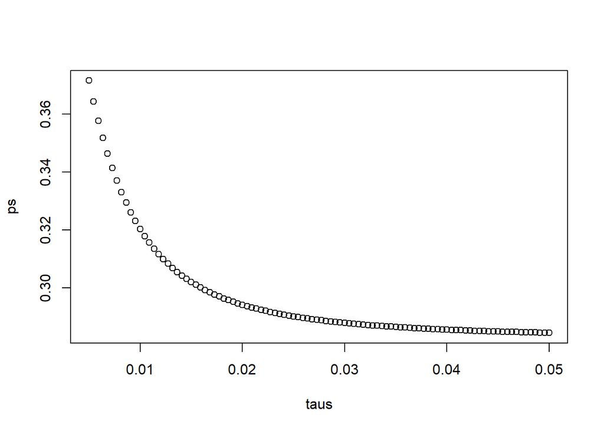

```r
# Define the variables from previous exercises
mu <- 0
sigma <- results$se
Y <- results$avg

# Define a variable `taus` as different values of tau
taus <- seq(0.005, 0.05, len = 100)

# Create a function called `p_calc` that generates `B` and calculates the probability of the spread being less than 0
p_calc <- function(tau) {
  B <- sigma ^ 2 / (sigma^2 + tau^2)
  se <- sqrt(1 / (1/sigma^2 + 1/tau^2))
  exp_value <- B * mu + (1 - B) * Y
  pnorm(0, exp_value, se)
}

# Create a vector called `ps` by applying the function `p_calc` across values in `taus`
ps <- p_calc(taus)

# Plot `taus` on the x-axis and `ps` on the y-axis
plot(taus, ps)
```